# Inquiline Genomics: Analyse CAFE modelling

# 1 2-parameter Models

## 1.1 Load all 2-parameter models

Load 2-parameter models from RUN5 (contains 8 independent runs for each 2-parameter model). These have been run iteratively to estimate individual rates for each branch in the analyzed phylogeny. Clustering in subsequent steps is based on these 2-parameter model estimates.

The table provides an overview of all eight repetitions of 2-parameter models for each branch.

| tree | lambda1 | lambda2 | score | mu1 | mu2 | scoreTmp | label |
| --- | --- | --- | --- | --- | --- | --- | --- |
| (((1,(1,1)1)1,(1,1)1)1,2) | 0.0007434245 | 3.148582e-04 | 27257.6 | 7.942853e-04 | 2.700000e-13 | 27257.6 | ACOL |
| (((1,(1,1)1)1,(1,1)1)1,2) | 0.0004485061 | 1.238965e-04 | 27355.4 | 1.173803e-03 | 3.100400e-10 | 27355.4 | ACOL |
| (((1,(1,1)1)1,(1,1)1)1,2) | 0.0005330572 | 9.426827e-05 | 27871.4 | 1.982311e-03 | 3.000000e-14 | 27871.4 | ACOL |
| (((1,(1,1)1)1,(1,1)1)1,2) | 0.0006206761 | 1.367575e-04 | 27246.7 | 8.481367e-04 | 4.600000e-13 | 27246.7 | ACOL |
| (((1,(1,1)1)1,(1,1)1)1,2) | 0.0006378240 | 2.085707e-04 | 27239.5 | 8.386960e-04 | 3.100000e-13 | 27239.5 | ACOL |
| (((1,(1,1)1)1,(1,1)1)1,2) | 0.0006049321 | 1.801698e-04 | 27285.5 | 1.094687e-03 | 7.730252e-07 | 27285.5 | ACOL |
| (((1,(1,1)1)1,(1,1)1)1,2) | 0.0007905171 | 2.075783e-03 | 28398.4 | 7.537630e-04 | 7.049000e-11 | 28398.4 | ACOL |
| (((1,(1,1)1)1,(1,1)1)1,2) | 0.0005502296 | 1.159140e-05 | 27339.1 | 9.313697e-04 | 1.227804e-07 | 27339.1 | ACOL |
| (((1,(1,1)1)1,(1,1)1)2,1) | 0.0005468409 | 6.654679e-04 | 27935.3 | 4.670289e-04 | 3.128939e-04 | 27935.3 | ACRO |
| (((1,(1,1)1)1,(1,1)1)2,1) | 0.0005467984 | 6.654828e-04 | 27935.3 | 4.670295e-04 | 3.128693e-04 | 27935.3 | ACRO |

[output cut: 70 more lines]

## 1.2 Select best fitting 2-parameter models

The figure shows the distribution of estimates for each branch. The red dot shows the lambda and mu estimates for the best-scoring model. The data frame shown provides an overview of the best-scoring 2-parameter models for each branch.

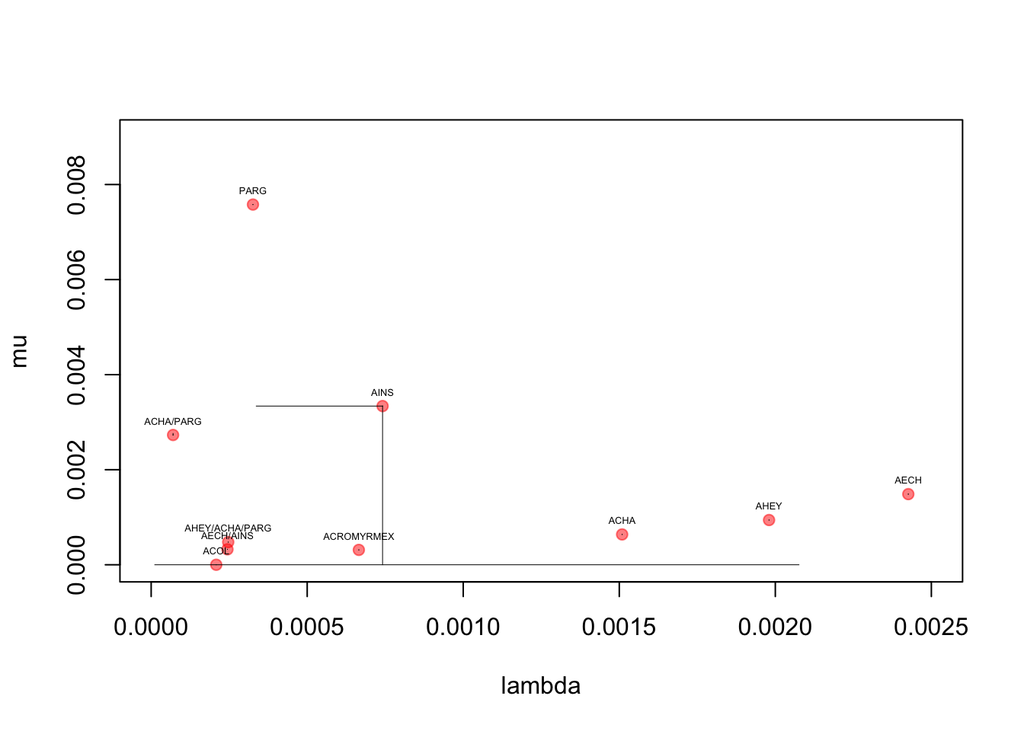

| label | tree | lambda1 | lambda2 | score | mu1 | mu2 | scoreTmp | minLambda | maxLambda | minMu | maxMu |
| --- | --- | --- | --- | --- | --- | --- | --- | --- | --- | --- | --- |
| ACHA | (((1,(2,1)1)1,(1,1)1)1,1) | 0.0005416641 | 1.509116e-03 | 27893.5 | 0.0003919985 | 6.381677e-04 | 27893.5 | 1.509023e-03 | 0.0015092192 | 6.379710e-04 | 6.381677e-04 |
| ACHA/PARG | (((1,(1,1)2)1,(1,1)1)1,1) | 0.0005950430 | 7.022335e-05 | 27830.8 | 0.0003664460 | 2.730328e-03 | 27830.8 | 7.013162e-05 | 0.0000706419 | 2.730095e-03 | 2.762304e-03 |
| ACOL | (((1,(1,1)1)1,(1,1)1)1,2) | 0.0006378240 | 2.085707e-04 | 27239.5 | 0.0008386960 | 3.100000e-13 | 27239.5 | 1.159140e-05 | 0.0020757832 | 3.000000e-14 | 7.730252e-07 |
| ACRO | (((1,(1,1)1)1,(1,1)1)2,1) | 0.0005468409 | 6.654679e-04 | 27935.3 | 0.0004670289 | 3.128939e-04 | 27935.3 | 6.654225e-04 | 0.0006655065 | 3.128670e-04 | 3.129027e-04 |
| AECH | (((1,(1,1)1)1,(2,1)1)1,1) | 0.0005266726 | 2.426159e-03 | 27842.8 | 0.0003967073 | 1.486123e-03 | 27842.8 | 2.426014e-03 | 0.0024265088 | 1.485836e-03 | 1.486360e-03 |
| AECH/AINS | (((1,(1,1)1)1,(1,1)2)1,1) | 0.0006332929 | 2.443868e-04 | 27906.5 | 0.0004382074 | 3.243041e-04 | 27906.5 | 2.443868e-04 | 0.0002444232 | 3.242449e-04 | 3.243518e-04 |
| AHEY | (((2,(1,1)1)1,(1,1)1)1,1) | 0.0004672083 | 1.979940e-03 | 27732.9 | 0.0003723550 | 9.411487e-04 | 27732.9 | 1.979940e-03 | 0.0019801353 | 9.409222e-04 | 9.411487e-04 |
| AHEY/ACHA/PARG | (((1,(1,1)1)2,(1,1)1)1,1) | 0.0006200806 | 2.468834e-04 | 27929.3 | 0.0004020575 | 4.769974e-04 | 27929.3 | 2.468162e-04 | 0.0002468922 | 4.769401e-04 | 4.770066e-04 |
| AINS | (((1,(1,1)1)1,(1,2)1)1,1) | 0.0005532773 | 7.415146e-04 | 27828.8 | 0.0003944002 | 3.338862e-03 | 27828.8 | 3.368370e-04 | 0.0007418529 | 1.155098e-06 | 3.341423e-03 |
| PARG | (((1,(1,2)1)1,(1,1)1)1,1) | 0.0005396527 | 3.261653e-04 | 26886.4 | 0.0002638173 | 7.578573e-03 | 26886.4 | 3.260611e-04 | 0.0003262213 | 7.578440e-03 | 7.578920e-03 |

## 1.3 Clustering of 2-parameter models

### 1.3.1 K-means clustering (n=1 to n=8) for 2-parameter models.

```r
# choose best estimates of the runs as basis for analysis
rate<-s5summary
#as.matrix(rate[2:nrow(rate),c(4,7)])
nmodels<-nrow(rate)
kclusters<-list()
for (i in 1:8){
  #kclusters[[i]]<-kmeans(as.matrix(rate[1:nmodels,c(4,7)]),i, algorithm = "MacQueen", nstart = 1000)
  #kclusters[[i]]<-kmeans(as.matrix(rate[1:nmodels,c(4,7)]),i, algorithm = "Hartigan-Wong", nstart = 1000)
  #kclusters[[i]]<-kmeans(as.matrix(rate[1:nmodels,c(4,7)]),i, algorithm = "Lloyd", nstart = 1000)
  kclusters[[i]]<-kmeans(as.matrix(rate[1:nmodels,c(4,7)]),i, nstart = 1000)
}
#kclusters
rate$k1<-as.factor(c(kclusters[[1]]$cluster))
rate$k2<-as.factor(c(kclusters[[2]]$cluster))
rate$k3<-as.factor(c(kclusters[[3]]$cluster))
rate$k4<-as.factor(c(kclusters[[4]]$cluster))
rate$k5<-as.factor(c(kclusters[[5]]$cluster))
rate$k6<-as.factor(c(kclusters[[6]]$cluster))
rate$k7<-as.factor(c(kclusters[[7]]$cluster))
rate$k8<-as.factor(c(kclusters[[8]]$cluster))
rate[,c(1:2,13:20)]
```

| label | tree | k1 | k2 | k3 | k4 | k5 | k6 | k7 | k8 |
| --- | --- | --- | --- | --- | --- | --- | --- | --- | --- |
| ACHA | (((1,(2,1)1)1,(1,1)1)1,1) | 1 | 1 | 1 | 1 | 2 | 4 | 6 | 7 |
| ACHA/PARG | (((1,(1,1)2)1,(1,1)1)1,1) | 1 | 1 | 2 | 4 | 4 | 2 | 3 | 5 |
| ACOL | (((1,(1,1)1)1,(1,1)1)1,2) | 1 | 1 | 1 | 2 | 5 | 6 | 7 | 6 |
| ACRO | (((1,(1,1)1)1,(1,1)1)2,1) | 1 | 1 | 1 | 2 | 5 | 6 | 7 | 4 |
| AECH | (((1,(1,1)1)1,(2,1)1)1,1) | 1 | 1 | 1 | 1 | 3 | 5 | 2 | 3 |
| AECH/AINS | (((1,(1,1)1)1,(1,1)2)1,1) | 1 | 1 | 1 | 2 | 5 | 6 | 7 | 6 |
| AHEY | (((2,(1,1)1)1,(1,1)1)1,1) | 1 | 1 | 1 | 1 | 2 | 4 | 5 | 1 |
| AHEY/ACHA/PARG | (((1,(1,1)1)2,(1,1)1)1,1) | 1 | 1 | 1 | 2 | 5 | 6 | 7 | 6 |
| AINS | (((1,(1,1)1)1,(1,2)1)1,1) | 1 | 1 | 2 | 4 | 4 | 3 | 1 | 2 |
| PARG | (((1,(1,2)1)1,(1,1)1)1,1) | 1 | 2 | 3 | 3 | 1 | 1 | 4 | 8 |

### 1.3.2 Kmeans Clustering results

The plot shows all different clusterings based on kmeans clustering. Dots show position according to 2-parameter model estimates.

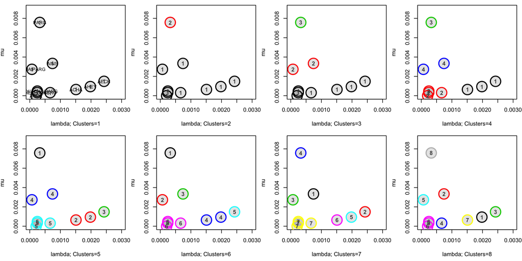

### 1.3.3 pamk unsupervised clustering/hierachical clustering

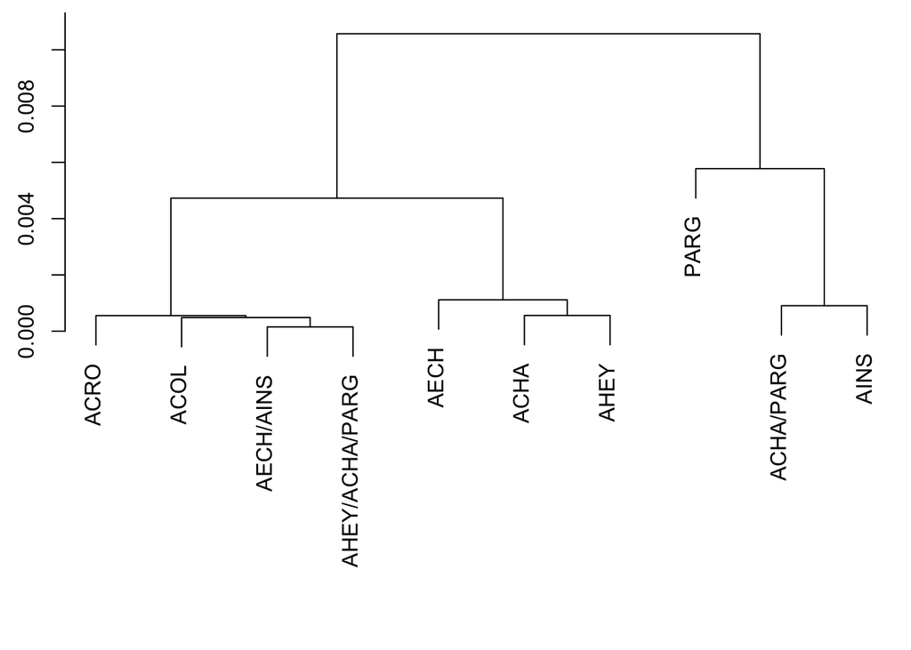

# 2 Model selection: higher-parameter models

We ran different clusters in CAFE to determine the best fitting model. A model with 6 clusters produced the best likelihood score. We continued to use this clustering for the final analysis of gene family evolution.

The plot shows these clusters. Numbered dots show position of each branch according to 2-parameter models. Coloring and ellipses are indicative of cluster membership (i.e. 6 colors for 6 clusters). Small red dots show estimates for the six different clusters. x= lambda estimates of gene gains, y= mu estimates of gene loss.

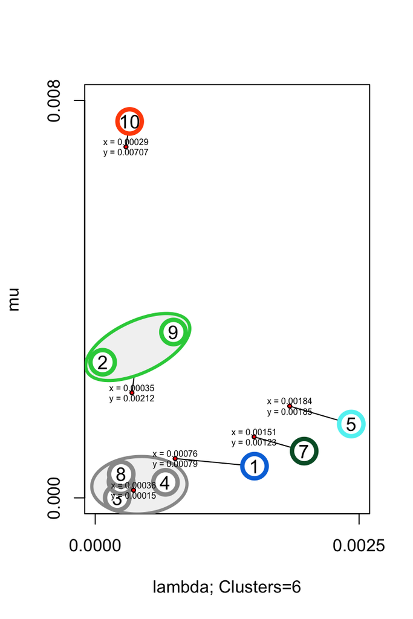